# **Part II - Effect of variables on the annual percentage rate of charge (APR) and on the A personalised risk score constructed from Prosper's historical data :**

```python
# import all packages and set plots to be embedded inline
import numpy as np
import pandas as pd
import matplotlib.pyplot as plt
import seaborn as sns

%matplotlib inline

# suppress warnings from final output
import warnings
warnings.simplefilter("ignore")
```

```python
# load in the dataset into a pandas dataframe
data = pd.read_csv("prosperLoanData.csv")
#List with all the variables
list_col=["LoanStatus" , "BorrowerRate", "StatedMonthlyIncome","Term","ProsperRating (Alpha)", "EmploymentStatus" , "LoanOriginalAmount","ProsperScore", "BorrowerAPR", "ListingCategory (numeric)","EmploymentStatusDuration" , "IsBorrowerHomeowner", "CurrentCreditLines","Occupation"]
data_etudes= data[list_col]
```

```python
#Convert type to category
list_a = ["HR" , "E" ,"D" ,"C" ,"B" , "A" ,"AA"]
cart_ordr = pd.api.types.CategoricalDtype(categories=list_a,ordered=True )
data_etudes["ProsperRating (Alpha)"].astype(cart_ordr)
# converting the type of the variable EmploymentStatus to a categorical type
ordre_list = ["Not available", "Not employed","Other","Retired" , "Part-time" ,"Full-time" , "Self-employed","Employed"]
category_list=pd.api.types.CategoricalDtype(ordre_list,ordered=True)
data_etudes.EmploymentStatus.astype(category_list)
```

```
0         Self-employed
1              Employed
2         Not available
3              Employed
4              Employed
              ...
113932         Employed
113933         Employed
113934         Employed
113935        Full-time
113936         Employed
Name: EmploymentStatus, Length: 113937, dtype: category
Categories (8, object): ['Not available' < 'Not employed' < 'Other' < 'Retired' < 'Part-time' < 'Full-time' < 'Self-employed' < 'Employed']
```

```python
#Removal of StatedMonthlyIncome values greater than 30000
data_etudes = data_etudes.query('StatedMonthlyIncome <= 30000')
#mask for data deletion with a score of 11
data_etudes=data_etudes.query('ProsperScore!=11')
```

> Note that the above cells have been defined as "Skip" slides. This means that that when the notebook is rendered as an http slide, these cells will not appear.

## Distribution of the Annual Percentage Rate (APR)

The distribution of the annual percentage rate in the data set shows a very wide range of values from about 0 to 0.51 with many peaks, the highest of which is about 0.35

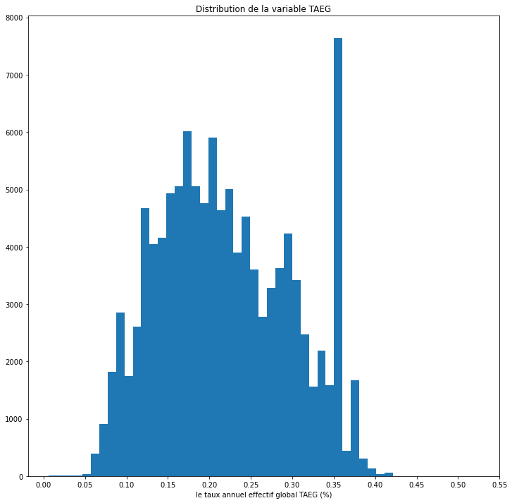

```python
plt.figure(figsize=(12,12))
plt.hist(data=data_etudes,x='BorrowerAPR',bins=50)
plt.xticks([0,0.05,0.1,0.15,0.2,0.25,0.3,0.35,0.4,0.45,0.5,0.55])
plt.xlabel("le taux annuel effectif global TAEG (%)")
plt.title("Distribution de la variable TAEG")
plt.show()
```

## Distribution of the initial loan amount

The initial loan amount is the amount of the loan without the interest rates. They have an asymmetrical distribution tilted to the right with values that are too large on the left. with values up to 35000$.

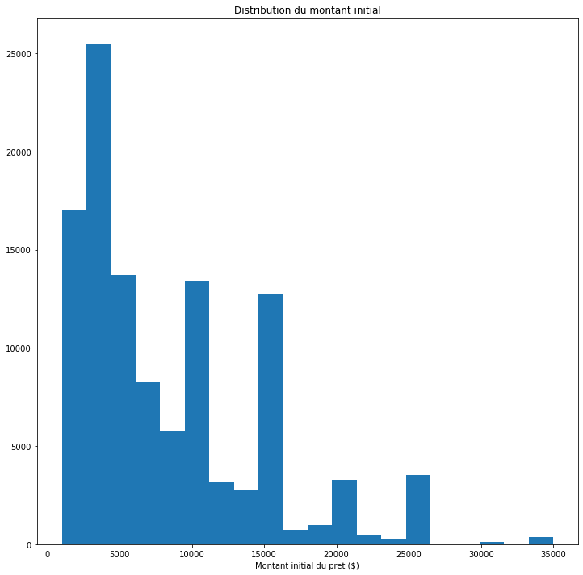

```python
plt.figure(figsize=(12,12))
plt.hist(data=data_etudes,x='LoanOriginalAmount',bins=20)
plt.xlabel("Montant initial du pret ($)")
plt.title("Distribution du montant initial")
plt.show()
```

## Loan duration distribution

Most loan applicants choose between 12 and 60 months to repay their loan. And most people opt for 36 months.

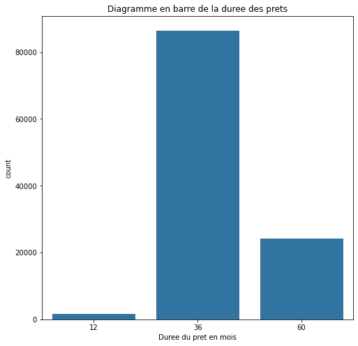

```python
plt.figure(figsize=(8,8))
color=sns.color_palette()[0]
sns.countplot(data=data_etudes,x='Term',color=color)
plt.xlabel("Duree du pret en mois")
plt.title("Diagramme en barre de la duree des prets")
plt.show()
```

```python
#Define a function for tracing
def diag_bar(col):
    plt.figure(figsize=(20,8))
    color = sns.color_palette()[0]
    #ordre=data_pret_etudes.col.value_counts().index.sort_values()
    sns.countplot(data=data_etudes,x=col,color=color)
    plt.xlabel(col)
    #plt.xticks(rotation=90)
    plt.title("distribution de " + col)
```

## Distribution ProsperRating (Alpha)

The bank assigns scores to each loan from AA to HR and we see that class C is the modal class

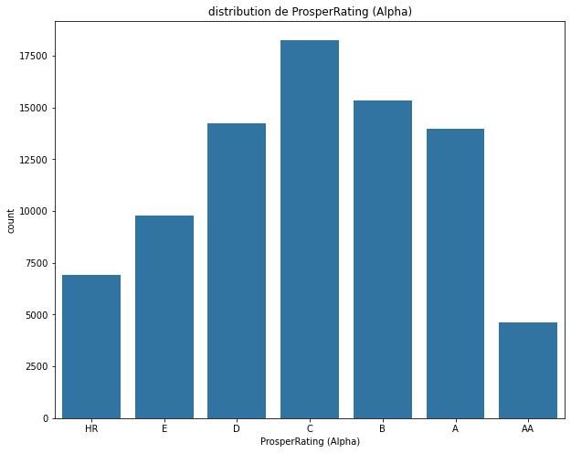

```python
ordre=["HR" , "E" ,"D" ,"C" ,"B" , "A" ,"AA"]
plt.figure(figsize=(10,8))
color = sns.color_palette()[0]
#ordre=data_pret_etudes.col.value_counts().index.sort_values()
sns.countplot(data=data_etudes,x='ProsperRating (Alpha)',color=color,order=ordre)
plt.xlabel("ProsperRating (Alpha)")
    #plt.xticks(rotation=90)
plt.title("distribution de ProsperRating (Alpha)" )
plt.show()
```

## Bar Chart of Custom Score

For the custom score the bank assigns them according to the history. 4 is the modal class

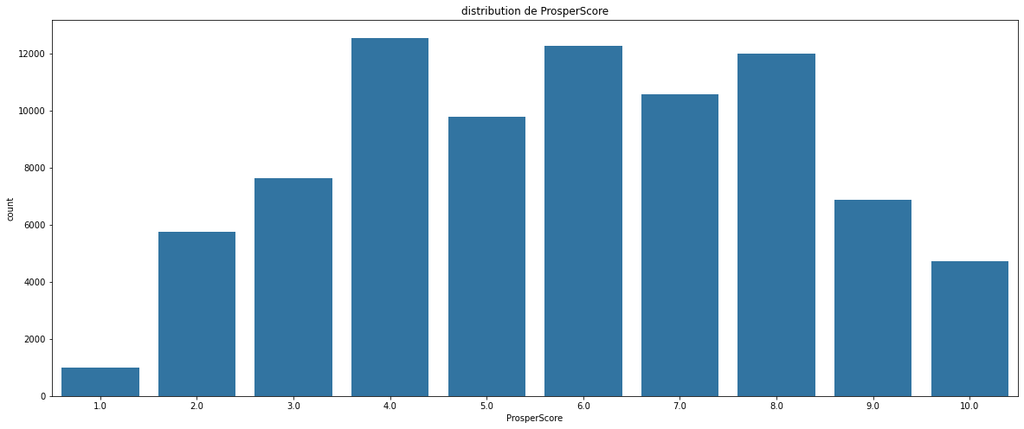

```python
diag_bar('ProsperScore')
```

## Initial amount as a function of duration

For the initial amount of the loan we found that the more the duration increases the higher the amount of the loan, so these two variables have a positive correlation, the increase of one leads to the increase of the other

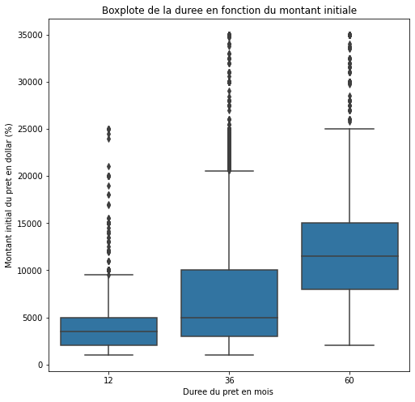

```python
plt.figure(figsize=(8,8))
color=sns.color_palette()[0]
sns.boxplot(data=data_etudes,x='Term',y=data_etudes.LoanOriginalAmount,color=color)
plt.xlabel("Duree du pret en mois ")
plt.ylabel("Montant initial du pret en dollar (%)")
plt.title("Boxplote de la duree en fonction du montant initiale")
plt.show()
```

## APR as a function of ProsperRating and loan term

The lowest rates correspond to ProsperRation values of AA followed by A and we can see that in these two modalities the rate increases with the duration so the relationship that we have highlighted above is confirmed by this graph

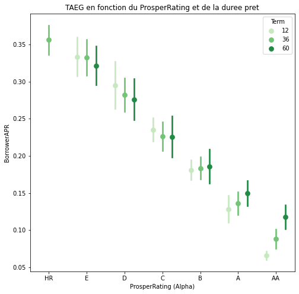

```python
plt.figure(figsize=(8,8))
sns.pointplot(data=data_etudes,x='ProsperRating (Alpha)',y='BorrowerAPR',hue='Term',palette='Greens',linestyles='',dodge=0.5,ci='sd',order=ordre)
plt.title("TAEG en fonction du ProsperRating et de la duree pret")
plt.show()
```

## Distribution of the APR according to the initial amount

Studies have confirmed the negative correlation between these two variables, the higher the amount, the lower the rate and vice versa

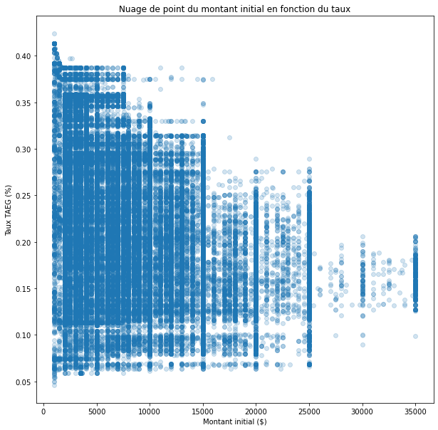

```python
plt.figure(figsize=(10,10))
plt.scatter(data=data_etudes.dropna(),y='BorrowerAPR',x='LoanOriginalAmount',alpha=0.2)
plt.xlabel('Montant initial ($)')
plt.ylabel('Taux TAEG (%)')
plt.title("Nuage de point du montant initial en fonction du taux")
plt.show()
```

```python
!jupyter nbconvert Part_II_slide_deck_template.ipynb --to slides --post serve --no-input --no-prompt
```

[output not shown]